# notebook9a5e000896

[figure not shown]

[figure not shown]

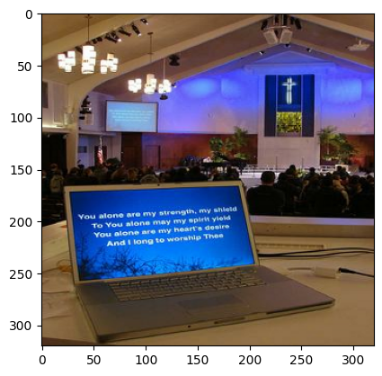

[figure not shown]

[figure not shown]

[figure not shown]

[figure not shown]

[figure not shown]

[figure not shown]

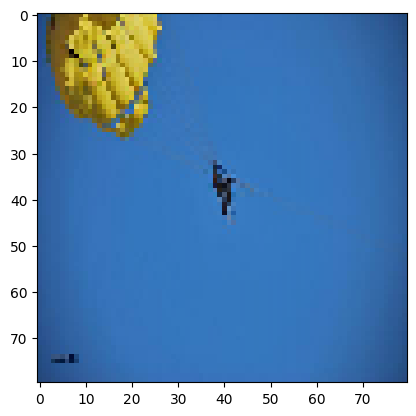

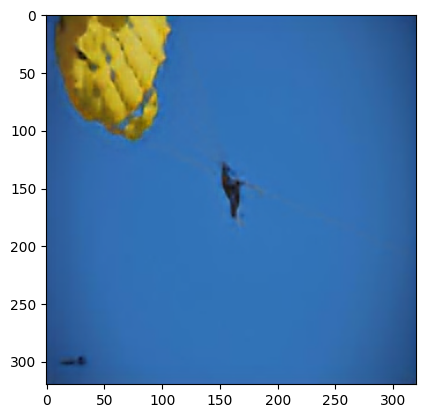

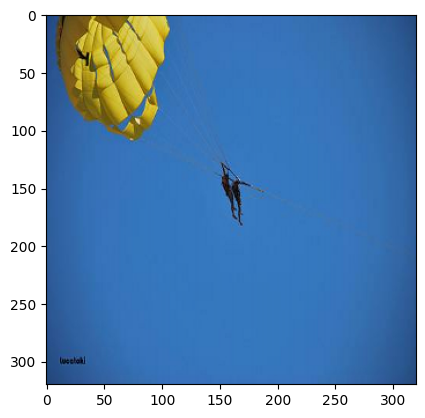

[18 more figures not shown]

```python
import math
for lr_batch, hr_batch in test_sr_ds.unbatch().batch(1).take(10):

    hr_img = hr_batch.numpy()
# Escollir algunes imatges de test aleatòries per a visualització
# Per a cada imatge
 # Llegir i processar una imatge de test
    lr_img = lr_batch.numpy()

 # Generar superresolució
    with suppress_stdout():
        hr_img_pred = suprel.predict(lr_img, batch_size=1)
 # Calcular PSNR

    psnr_of_image = tf.image.psnr(hr_img,hr_img_pred,max_val=1.0)
 # Preparar imatges per visualitzar de la mateixa mida

 # Les imatges estan a [0,1], escalar a [0,255] per mostrar correctament
    hr_img_pred = (hr_img_pred[0]*255).astype(np.int32)
    hr_img = (hr_img[0]*255).astype(np.int32)
    lr_img = (lr_img[0]*255).astype(np.int32)
 # Mostrar les imatges
    plt.imshow(lr_img)
    plt.show()
    plt.imshow(hr_img_pred)
    plt.show()
    plt.imshow(hr_img)
    plt.show()
```

**Comentaris:**  
Anàlisi dels resultats del model SR:

- **PSNR** : Veiem que els PSNR esta al voltant del 23 Db la qual es una perdua d'informacio molt acceptable per una comunicacio inalambrica
- **Qualitat visual** : Visualment veiem una recontruccio pero es veuen com si difuminesim la imatge també es a considerar que la imatge de partida es bastant petita i estem reconstruint apartir d'un 16 de la informació per tant crec que es un resultat suficientment positiu
- **Errors** : Veiem que el que costa mes replicar es el text, per exemple al camio publicitari de hockey el text es illegible a la reconstruccio, també veiem com una difuminacio general

Crec que el model és un model senzill amb poca informacio (nomes 10000) casos pero inclus aixì podem veure una reconstruccio bastant bona

## 7. Model pre-entrenat en superresolució (1 punt)

Els avenços recents en superresolució han produït arquitectures més complexes (p. ex., basades en xarxes generatives adversàries) que aconsegueixen resultats notablement millors, a costa d'un entrenament costós. Un d'aquests models és ESRGAN ([Enhanced Super-Resolution GAN per Xintao Wang et al.](https://arxiv.org/abs/1809.00219)), entrenat en grans bases de dades d'imatges HD (com DIV2K) per aconseguir superresolució 4x de gran fidelitat.

Farem servir un model pre-entrenat d'ESRGAN disponible via [TensorFlow Hub](https://www.tensorflow.org/hub/tutorials/image_enhancing)

Aquest model ha estat entrenat al conjunt DIV2K (imatges d'alta qualitat) amb degradació bicúbica, per la qual cosa està especialitzat en produir imatges 4× més grans amb detall notable.

Farem servir ESRGAN per aplicar superresolució a les mateixes imatges de test i compararem els resultats amb el nostre model implementat a l'exercici 5.

**Exercici 7 [1 pt]:** Utilitza un model pre-entrenat de superresolució (p. ex. ESRGAN 4×) per millorar les imatges de baixa resolució. En concret:

- Carrega el model pre-entrenat des de TensorFlow Hub (usa l'URL proporcionada, per exemple `"https://tfhub.dev/captain-pool/esrgan-tf2/1"`).
- Per a una selecció d'imatges de test de baixa resolució (80×80), obteniu la superresolució 4× amb aquest model.
- Calcula la PSNR de les imatges generades pel model pre-entrenat (en el total del conjunt de test) i compara la seva mitjana amb la PSNR mitjana obtinguda pel teu model.
- Visualitza les imatges de sortida del model pre-entrenat al costat de les del teu model i les originals, per comparar visualment la qualitat. Compara també la PSNR d'aquestes imatges.

Discuteix les diferències observades:

- El model pre-entrenat obté millors mètriques?
- El model pre-entrenat produeix imatges més nítides i properes a la realitat?
- En quins detalls es nota la millora?

```python
import tensorflow_hub as hub

# Carreguem el model ESRGAN des de TF-Hub:
esrgan = hub.load("https://www.kaggle.com/models/kaggle/esrgan-tf2/TensorFlow2/esrgan-tf2/1")
print("Model ESRGAN carregat.")
```

```
Model ESRGAN carregat.
```

```python
# Llista per emmagatzemar la PSNR de cada imatge usant ESRGAN
import contextlib
@contextlib.contextmanager
def suppress_stdout():
    with open(os.devnull, "w") as devnull:
        old_stdout = os.sys.stdout
        os.sys.stdout = devnull
        try:
            yield
        finally:
            os.sys.stdout = old_stdout

psnr_of_images = []
# Recórrer el dataset de test (batch size = 1)
for lr_batch, hr_batch in test_sr_ds.unbatch().batch(1):
    lr_img = lr_batch.numpy()
    hr_img = hr_batch.numpy()
 # Preparar la imatge LR per ESRGAN:
 # ESRGAN espera entrada en rang [0,255] com a float32, i test_sr_ds té imatges a [0,1]
    lr_img = (lr_img*255).astype(np.float32)
 # Generar la imatge de superresolució amb ESRGAN
    with suppress_stdout():
        hr_img_pred = esrgan(lr_img)
 # Treure la dimensió de batch i normalitzar la sortida a [0,1]
    hr_img_pred = hr_img_pred[0]/255
 # Obtenir la imatge HR corresponent (llevem la dimensió de batch)
    hr_img = hr_img[0]
 # Calcular la PSNR entre la imatge generada per ESRGAN i la imatge HR original
    psnr_of_image = tf.image.psnr(hr_img,hr_img_pred,max_val=1.0)
    psnr_of_images.append(psnr_of_image)

# Calcular la PSNR mitjana en el conjunt de test amb ESRGAN
avg_psnr_esrgan = np.mean(psnr_of_images)
print("PSNR mitjana en el conjunt de test amb ESRGAN: {:.2f} dB".format(avg_psnr_esrgan))
```

```
PSNR mitjana en el conjunt de test amb ESRGAN: 18.59 dB
```

```
tf.Tensor([-40.696487], shape=(1,), dtype=float32)
```

[figure not shown]

[figure not shown]

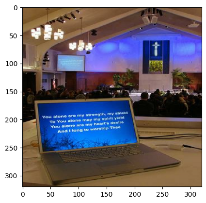

```
tf.Tensor([-42.263454], shape=(1,), dtype=float32)
```

[figure not shown]

[figure not shown]

[figure not shown]

```
tf.Tensor([-42.655365], shape=(1,), dtype=float32)
```

[figure not shown]

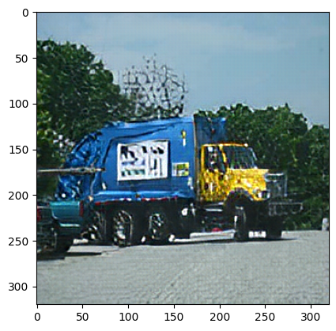

[figure not shown]

```
tf.Tensor([-42.09392], shape=(1,), dtype=float32)
```

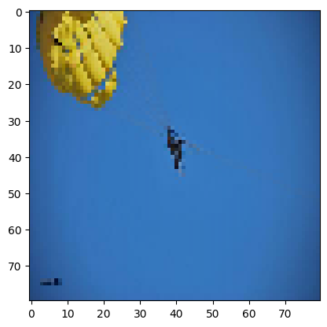

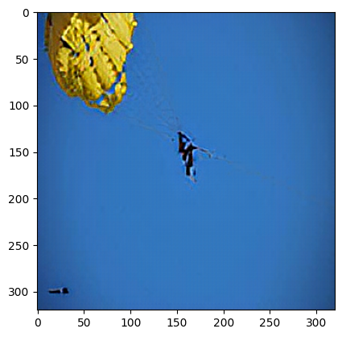

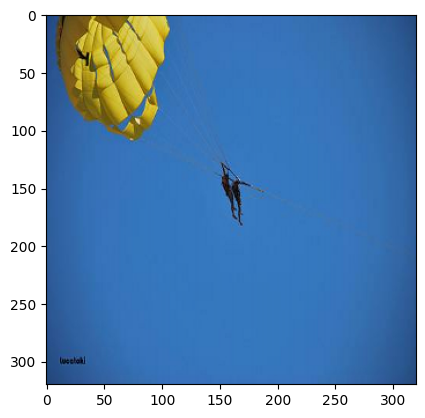

```
tf.Tensor([-39.79628], shape=(1,), dtype=float32)
```

[18 more figures not shown]

```python
import math


# Apliquem ESRGAN a les mateixes imatges d'exemple que fem servir amb el nostre model
for lr_batch, hr_batch in test_sr_ds.unbatch().batch(1).take(10):

    hr_img = hr_batch.numpy()
# Per a cada imatge

 # Preparar la imatge LR de test
    lr_img = lr_batch.numpy()
    lr_img = (lr_img*255).astype(np.float32)
 # Convertir sortida a [0,1] float
    with suppress_stdout():
        hr_img_pred = esrgan(lr_img)
 # Calcular PSNR comparat amb HR
    psnr_of_image = tf.image.psnr(hr_img,hr_img_pred,max_val=1.0)
 # Visualitzar comparativa
    hr_img_pred = hr_img_pred.numpy()
    hr_img_pred = (hr_img_pred[0]).astype(np.int32)
    hr_img = (hr_img[0]*255).astype(np.int32)
    lr_img = (lr_img[0]).astype(np.int32)
 # Mostrar les imatges
    print(psnr_of_image)
    plt.imshow(lr_img)
    plt.show()
    plt.imshow(hr_img_pred)
    plt.show()
    plt.imshow(hr_img)
    plt.show()
```

## 8. Comparació i conclusions (0,5 pts)

En aquesta pràctica hem explorat tant la classificació d’imatges amb xarxes neuronals (denses vs convolucionals) com la superresolució amb CNNs, aplicant-ho tot sobre la base de dades d’Imagenette.

**Exercici 8 [0,5 pts]:** Fes un resum dels punts apresos en aquest PAC. Concretament, resumeix en una frase el que has après de cadascun dels punts enumerats a continuació:

- **ANN vs CNN:**
- **Regularització i augmentació:**
- **Superresolució:**
- **Transfer learning:**

Valoració final

**Comentaris:**  
Conclusions finals:

- **ANN vs CNN:** Les ANN són una eina molt bona pero en procesament d'imatge veiem que les CNN són més ultils ja que en menys temps d'execucio i amb menys parametres arriben a millors conclusions
- **Regularització i augmentació:** La regularització es necesaria per obtenir models de qualitat evitant biaxos i la augmentació es una manera molt fácil d'augmentar la quantitat de dades que tenim i guanyar generalització aplicant nomes tranformacions elementals
- **Superresolució:** Es una eina que pot ser molt util sobre tot amb models més robustos, un us molt util que se li podria donar es la compresio d'imatges sense perdua de informacio, on podriem tenir les images guardades en LR i per mostrarles utilitzar el model per mostrarles en HR aixì estalviant-nos espai d'almacenatge
- **Transfer Learning:** La ventage es molt clara, sobre tot si no has d'entrenar el model ja que no requereix temps d'entrenament al instant tens un model el qual ja es funcional sense necesitat de esperar a l'entrenamet, que en el nostre cas eren models petits pero suposant un model més gran amb un dataset molt més gran podriem tardar molt en entrenar-lo o utilitzar un model que nosaltres no podriem entrenar ja que no tenim la infrastructura ni la obtencio de dades de un altre organitzacio. Per tant si podem utilitzar un model ja existent perque s'ajusta prou bé a les nostres dades crec que es una molt bona idea

Clarament les xarxes neuronals son molt utils té moltes aplicaccions pero no es podem oblidar de la literatura acutal ja que pot ser s'ha vist quina arquitectura es la millor per capturar certes caracteristiques i inclus podem trobar un model ja entrenat que podem utilitzar directament sense necesitat de entrenar-lo nosaltes